# 08.1: Cluster Architecture

[figure not shown]

# 2 / 14: Big Data: Storing and Computing

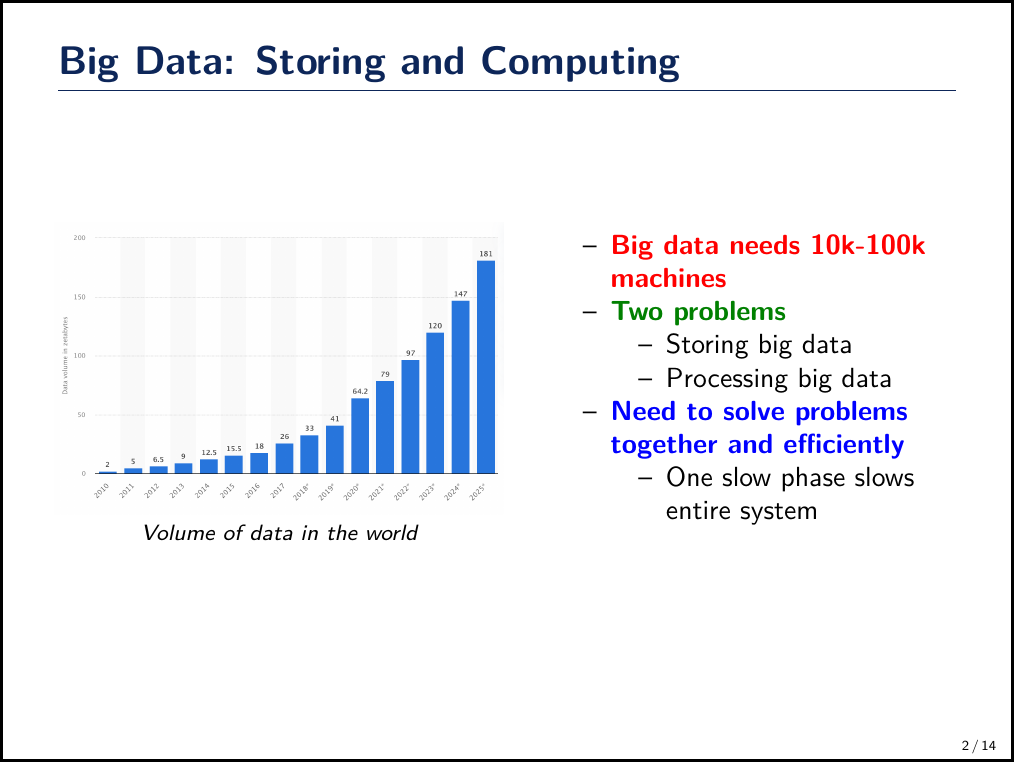

- **Big data needs 10k-100k machines**
  - As the volume of data grows exponentially, managing it requires a vast number of machines. This scale is necessary to handle the storage and processing demands efficiently.
  - The graph illustrates the rapid increase in data volume, highlighting the need for substantial computational resources.
- **Two problems**
  - *Storing big data*: With data volumes reaching zettabytes, traditional storage solutions are inadequate. New methods and technologies are needed to store this data efficiently and cost-effectively.
  - *Processing big data*: Beyond storage, the ability to process and analyze data quickly is crucial. This requires powerful computing resources and optimized algorithms.
- **Need to solve problems together and efficiently**
  - Both storage and processing must be addressed simultaneously. If one aspect lags, it can bottleneck the entire system, reducing overall efficiency.
  - Integrated solutions that optimize both storage and processing are essential to handle the growing data demands effectively.

# 3 / 14: Processing the Web: Example

[figure not shown]

- **Web contains (in 2024):**
  - The web is vast, with over 20 billion pages. This highlights the immense scale of information available online.
  - The content amounts to 5 million terabytes (TB), illustrating the massive data volume that needs to be managed and processed.
- **Storing the web:**
  - To store the entire web, you would need 1 million hard drives, each with a capacity of 5TB. This gives a sense of the physical storage requirements.
    - At a cost of $100 per hard drive, the total expense would be $100 million, which is surprisingly affordable given the scale.
  - However, a single computer reading at 300 MB per second would take 4,500 years to read all this data sequentially. This emphasizes the impracticality of processing such data with traditional methods.
- **Processing the web:**
  - The time and cost required to process the web are significantly larger than just storing it. This underscores the challenges in handling and analyzing such vast amounts of data efficiently.

The image visually represents the complexity and interconnectedness of the internet, reinforcing the scale and intricacy of web data.

# 4 / 14: How to Store Big Data?

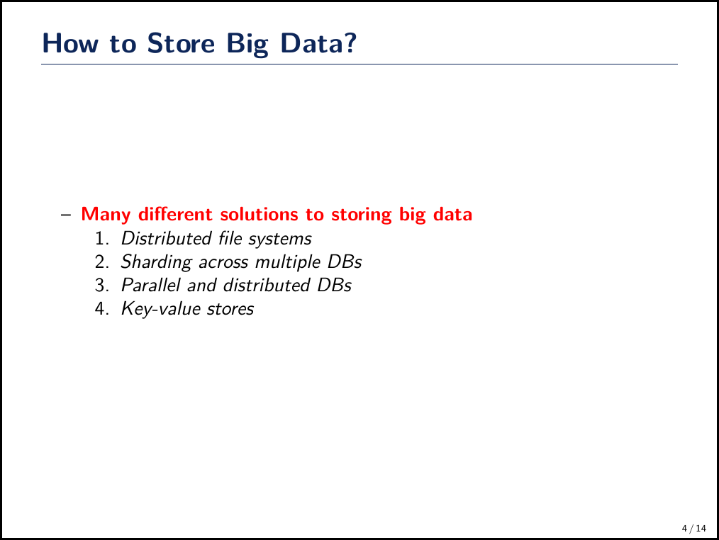

# 5 / 14: 1) Distributed File Systems

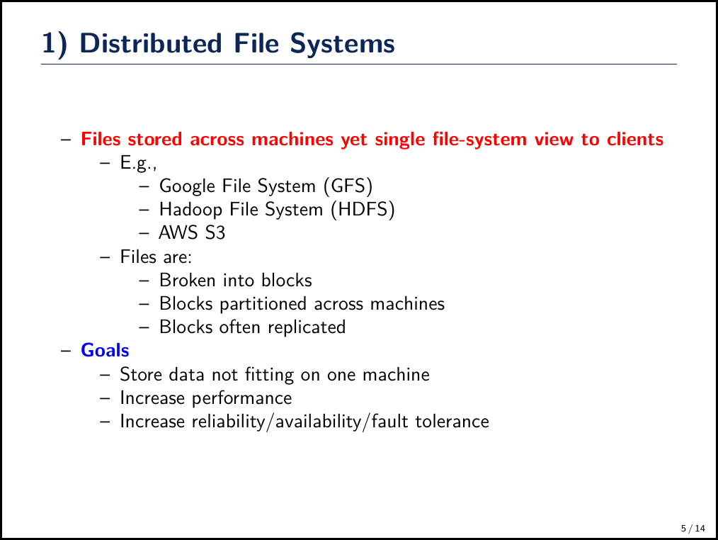

- **Distributed File Systems**
- *Files stored across machines yet single file-system view to clients*
  - Distributed file systems allow files to be stored across multiple machines, but they appear as a single file system to users. This means that even though the data is spread out, it feels like you’re accessing files from one place.
  - **Examples**:
    - **Google File System (GFS)**: Developed by Google to handle large-scale data processing.
    - **Hadoop File System (HDFS)**: Part of the Hadoop ecosystem, designed for big data applications.
    - **AWS S3**: Amazon’s cloud storage service that provides scalable storage for data.
  - **Files are**:
    - **Broken into blocks**: Large files are divided into smaller pieces called blocks to manage and store them efficiently.
    - **Blocks partitioned across machines**: These blocks are distributed across different machines to balance the load and optimize storage.
    - **Blocks often replicated**: To ensure data safety and availability, blocks are usually copied multiple times across different machines.
- *Goals*
  - **Store data not fitting on one machine**: Distributed file systems are essential for handling massive datasets that exceed the storage capacity of a single machine.
  - **Increase performance**: By distributing data, these systems can process and retrieve data faster, improving overall performance.
  - **Increase reliability/availability/fault tolerance**: Replicating data across machines ensures that even if one machine fails, the data remains accessible and safe, enhancing system reliability and fault tolerance.

# 6 / 14: 2) Sharding Across Multiple DBs

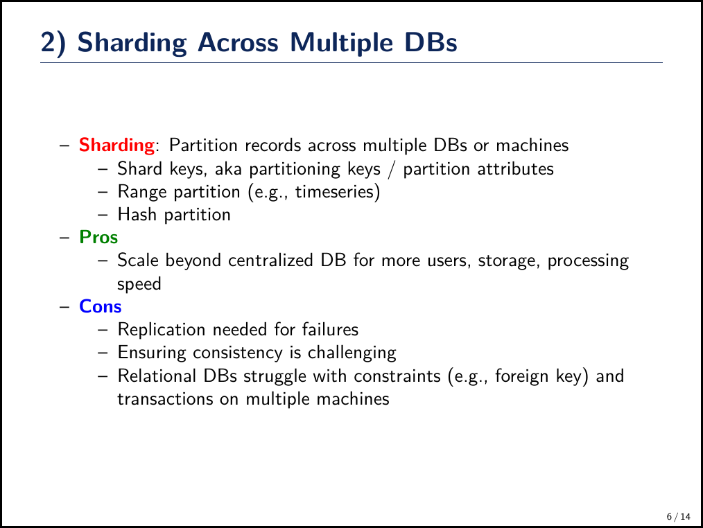

- **Sharding**: This is a method used to divide and store data across multiple databases or machines. The main goal is to manage large datasets more efficiently by distributing the load.
- **Shard keys**: These are specific attributes or keys used to determine how data is partitioned. They are crucial because they dictate how data is distributed across different shards.
- **Range partition**: This involves dividing data based on a specific range of values, such as dates in a timeseries database. It’s useful for organizing data that naturally falls into sequential ranges.
- **Hash partition**: This method uses a hash function to distribute data evenly across shards. It’s often used to ensure a balanced distribution of data, avoiding hotspots.
- **Pros**:
  - Sharding allows a database to scale beyond the limitations of a single, centralized database. This means it can handle more users, store more data, and process requests faster.
- **Cons**:
  - To prevent data loss in case of failures, replication of data across shards is necessary, which can be complex.
  - Maintaining data consistency across multiple shards is a significant challenge, especially when data is frequently updated.
  - Relational databases often face difficulties with enforcing constraints like foreign keys and managing transactions when data is spread across multiple machines. This can complicate database operations and integrity.

# 7 / 14: 3) Parallel and Distributed DBs

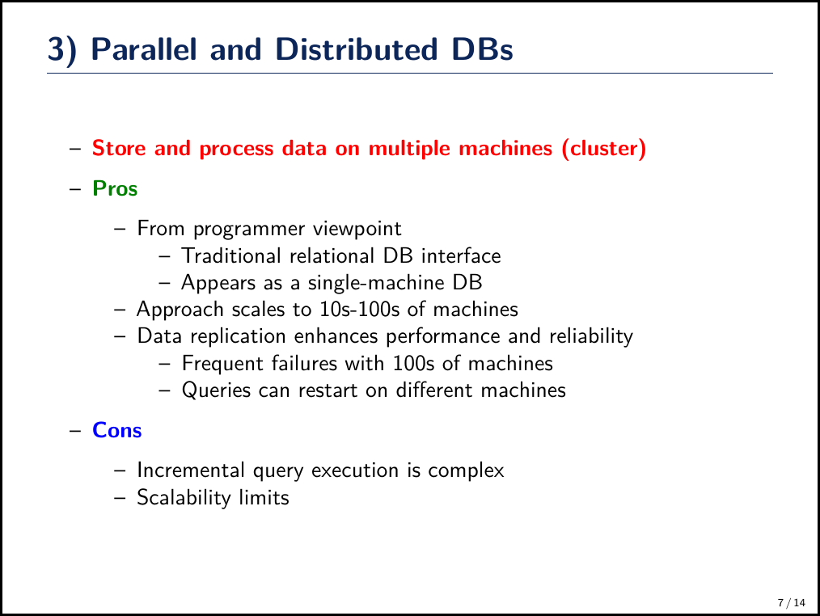

- **Parallel and Distributed DBs**: These databases are designed to handle large volumes of data by distributing the storage and processing tasks across multiple machines, often referred to as a *cluster*. This setup allows for more efficient data management and processing.
- **Pros**:
  - **From programmer viewpoint**: Developers can interact with these databases using a traditional relational database interface, which means they don’t need to learn new tools or languages. The system is designed to appear as if it is a single-machine database, simplifying the development process.
  - **Scalability**: This approach can effectively scale to accommodate 10s to 100s of machines, allowing for significant growth in data handling capacity without a complete overhaul of the system.
  - **Data replication**: By replicating data across multiple machines, the system can enhance both performance and reliability. This is crucial because with hundreds of machines, failures are more common. If one machine fails, queries can be restarted on another machine, minimizing downtime and data loss.
- **Cons**:
  - **Incremental query execution is complex**: Managing and executing queries incrementally across multiple machines can be challenging. This complexity arises from the need to coordinate and synchronize data processing tasks across the distributed system.
  - **Scalability limits**: Although these systems can scale to a large number of machines, there are still limits to how far they can scale efficiently. Beyond a certain point, the overhead of managing the distributed system can outweigh the benefits, leading to diminishing returns in performance improvements.

# 8 / 14: 4) (Parallel) Key-value Stores

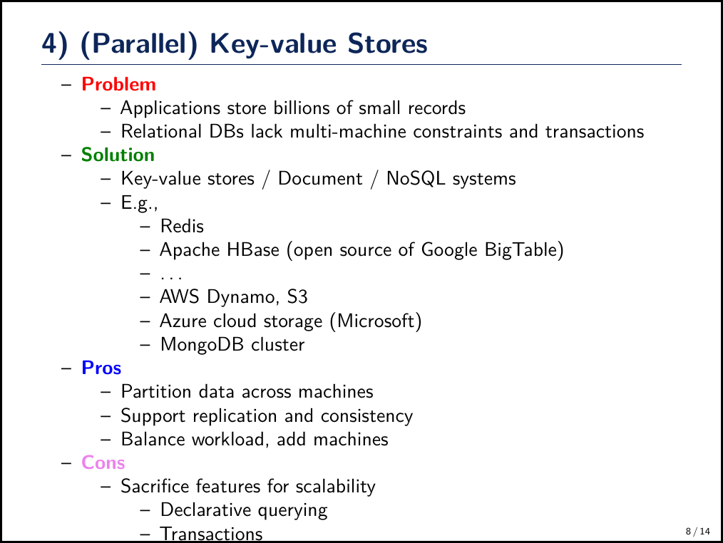

# 9 / 14: How to Compute with Big Data?

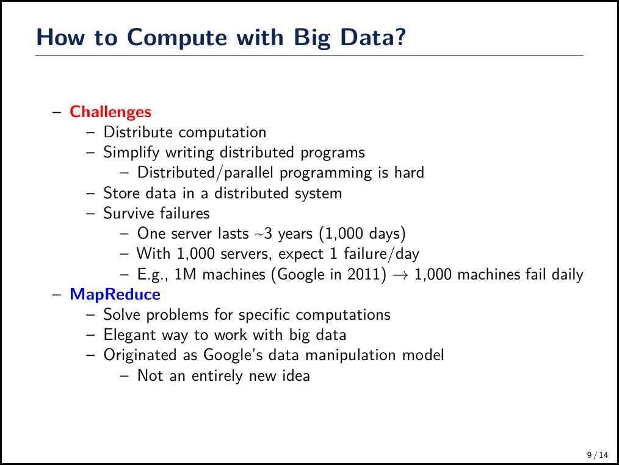

- **How to Compute with Big Data?**
- **Challenges**
  - **Distribute computation**: When dealing with big data, it’s crucial to spread the workload across multiple computers. This helps in processing large datasets efficiently.
  - **Simplify writing distributed programs**: Writing programs that run on multiple computers at once is complex. It’s not easy to manage how these computers communicate and work together.
  - **Store data in a distributed system**: Big data requires storage systems that can handle vast amounts of information spread across many machines.
  - **Survive failures**: Computers can fail, and with many machines, failures are frequent. For example, a single server might last about three years. If you have 1,000 servers, you might expect one to fail every day. Companies like Google, which had around a million machines in 2011, could see about 1,000 failures daily.
- **MapReduce**
  - **Solve problems for specific computations**: MapReduce is a method designed to handle specific types of data processing tasks efficiently.
  - **Elegant way to work with big data**: It provides a straightforward approach to process large datasets by breaking down tasks into smaller, manageable parts.
  - **Originated as Google’s data manipulation model**: Google developed MapReduce to handle their massive data needs. While it was innovative, the concept of dividing tasks wasn’t entirely new.

# 10 / 14: Cluster Architecture

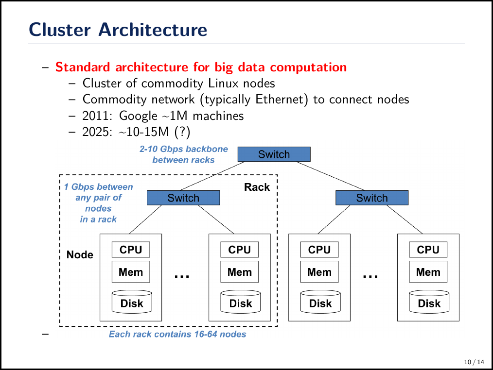

- **Cluster Architecture**
- **Standard architecture for big data computation**
  - *Cluster of commodity Linux nodes*: This refers to using affordable, widely available hardware running Linux to build a cluster. These nodes work together to handle large-scale data processing tasks.
  - **Commodity network (typically Ethernet) to connect nodes**: Ethernet is commonly used to connect these nodes, providing a cost-effective and reliable networking solution.
  - **2011: Google ~1M machines**: By 2011, Google had approximately one million machines in its data centers, showcasing the scale of infrastructure needed for big data processing.
  - **2025: ~10-15M (?)**: This projection suggests a significant increase in the number of machines, reflecting the growing demand for data processing capabilities.
- **Diagram Explanation**
  - The diagram illustrates a typical cluster setup:
    - **Node**: Each node contains a CPU, memory, and disk storage, forming the basic unit of computation and storage.
    - **Rack**: A collection of nodes, typically 16-64, connected by a switch. Nodes within a rack communicate at 1 Gbps.
    - **Switches**: Connect racks with a backbone network, providing 2-10 Gbps between racks, facilitating efficient data transfer across the cluster.

# 11 / 14: Cluster Architecture

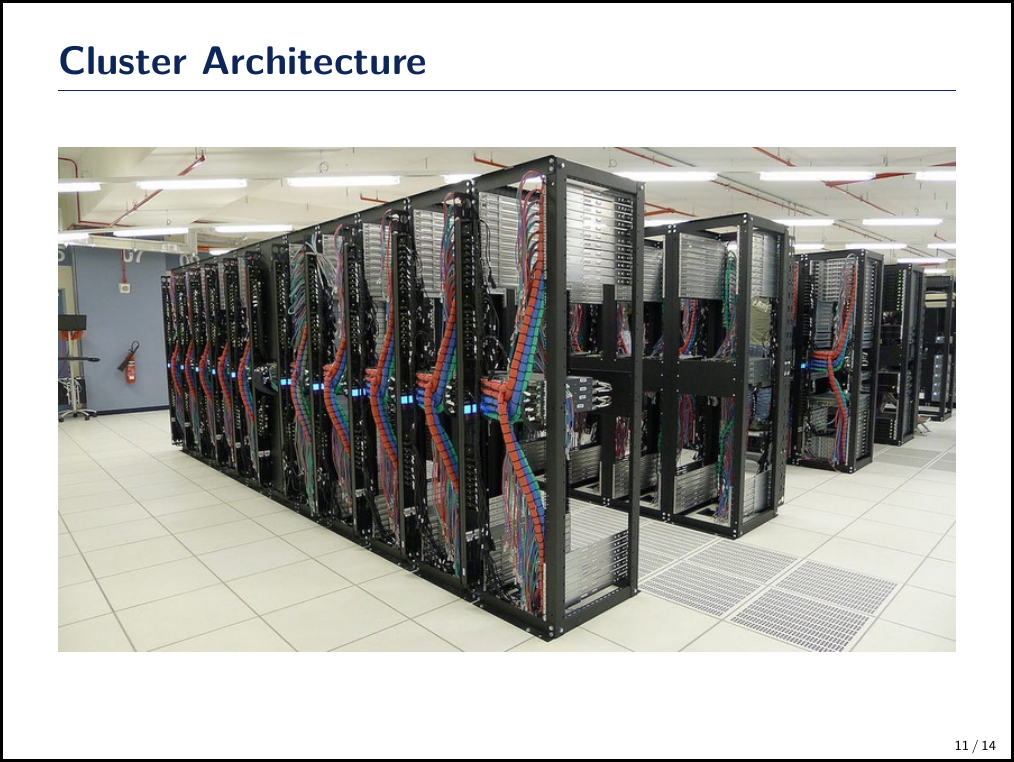

- **Cluster Architecture**
  - *Definition*: A cluster architecture refers to a group of interconnected computers that work together as a single system to provide high availability, scalability, and performance.
  - **Components**:
    - *Nodes*: Each computer in the cluster is called a node. Nodes can be physical machines or virtual instances.
    - *Networking*: Nodes are connected through a network, allowing them to communicate and share resources.
    - *Storage*: Shared or distributed storage systems are often used to ensure data availability and redundancy.
  - **Benefits**:
    - *Scalability*: Easily add more nodes to increase computing power.
    - *Fault Tolerance*: If one node fails, others can take over its tasks, minimizing downtime.
    - *Load Balancing*: Distributes workloads evenly across nodes to optimize resource use.
  - **Use Cases**:
    - Commonly used in data centers, cloud computing, and high-performance computing environments.
    - Ideal for applications requiring large-scale data processing, such as big data analytics and scientific simulations.

# 12 / 14: Cluster Architecture: Network Bandwidth

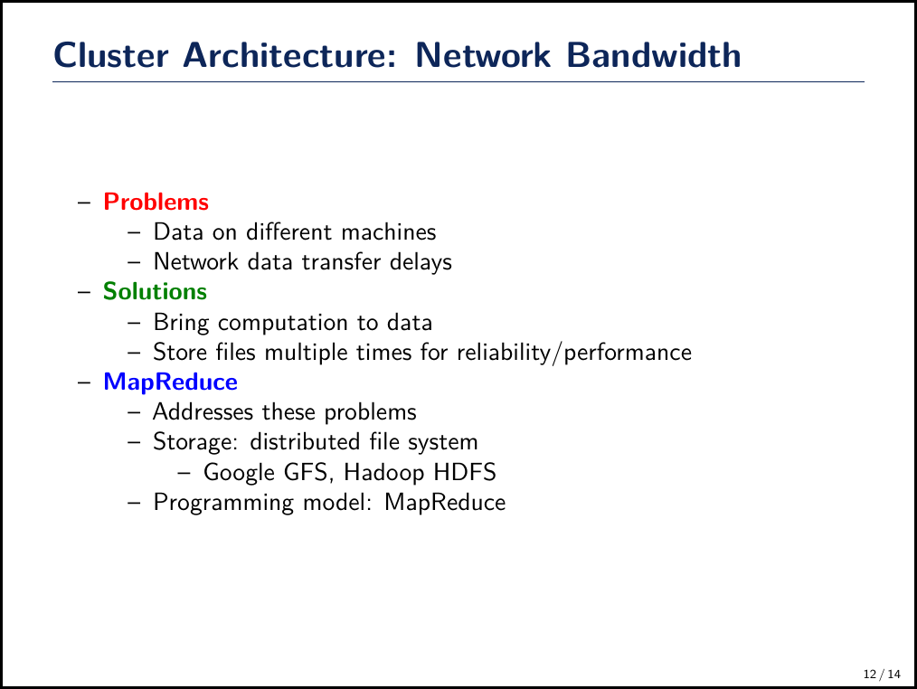

# 13 / 14: Storage Infrastructure

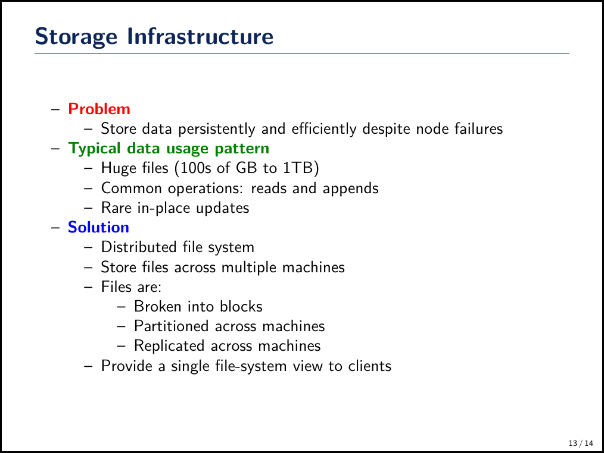

# 14 / 14: Distributed File System

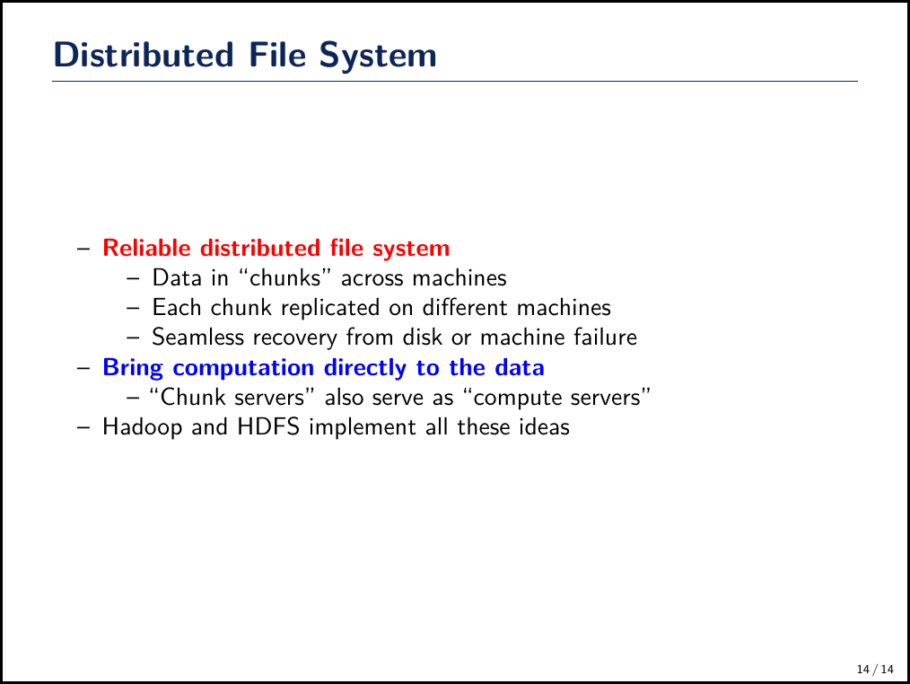

- **Distributed File System**
- *Reliable distributed file system*
  - **Data in “chunks” across machines**: In a distributed file system, data is broken down into smaller pieces called “chunks.” These chunks are stored across multiple machines in a network. This approach helps in managing large datasets efficiently and ensures that the system can handle large volumes of data without any single machine becoming a bottleneck.
  - **Each chunk replicated on different machines**: To ensure data reliability and availability, each chunk is copied and stored on multiple machines. This replication means that if one machine fails, the data is still accessible from another machine, minimizing the risk of data loss.
  - **Seamless recovery from disk or machine failure**: The system is designed to automatically recover from failures. If a disk or machine fails, the system can quickly switch to using the replicated data from other machines, ensuring continuous operation without significant downtime.
- *Bring computation directly to the data*
  - **“Chunk servers” also serve as “compute servers”**: In this model, the servers that store the data chunks also perform computations on the data. This reduces the need to move large amounts of data across the network, which can be time-consuming and resource-intensive. By processing data where it is stored, the system becomes more efficient and faster.
- **Hadoop and HDFS implement all these ideas**: Hadoop is a popular framework that uses the Hadoop Distributed File System (HDFS) to implement these concepts. HDFS is designed to store and manage large datasets across distributed systems, making it a key component in big data processing. Hadoop leverages these principles to provide a scalable and reliable platform for data storage and processing.